# Cyclistic Bike-Share Case Study

Chimezie Desmond Ofaraka

2025-12-21

### Executive Summary

Cyclistic is a bike-share company whose future growth depends on increasing the number of annual members. This analysis compares the behavior of casual riders and annual members using historical trip data from Q1 2019 and Q1 2020.

Based on these insights, Cyclistic should focus on weekend-focused and leisure-based incentives to convert casual riders into annual members.

### Business Task

The business objective is to understand how casual riders and annual members use Cyclistic bikes differently in order to design a marketing strategy that converts casual riders into annual members.

**Key question:**  
How do casual riders differ from annual members in their riding behavior?

### Data Sources

This analysis uses two publicly available datasets provided by Cyclistic (Divvy):

- **Divvy_Trips_2019_Q1.csv**
- **Divvy_Trips_2020_Q1.csv**

Each dataset contains individual trip-level data including timestamps, station information, ride duration, and rider type.

### Data Cleaning & Preparation

```r
library(tidyverse)
library(readr)
library(lubridate)
```

#### Load Data

```r
trip1_2019 <- read_csv("data/Divvy_Trips_2019_Q1.csv")
trip1_2020 <- read_csv("data/Divvy_Trips_2020_Q1.csv")
```

#### Inspect Data

```r
colnames(trip1_2019)
colnames(trip1_2020)

glimpse(trip1_2019)
glimpse(trip1_2020)
```

#### Standardize Column Names (2019)

```r
 trip1_2019_clean <- trip1_2019 %>%
   rename(ride_id = trip_id,
     started_at = start_time,
     ended_at = end_time,
     start_station_id = from_station_id,
     start_station_name = from_station_name,
     end_station_id = to_station_id,
     end_station_name = to_station_name,
     member_casual = usertype) %>%
   mutate(ride_length = tripduration / 60)
```

#### Ride_length Data Validation

```r
trip1_2019_clean %>%
   mutate(calc_length = as.numeric(difftime(ended_at, started_at, units = "mins"))) %>%
   summarise(avg_ride_l = mean(ride_length, na.rm = TRUE),
             avg_calc_l = mean(calc_length, na.rm = TRUE))
```

```
## # A tibble: 1 × 2
##   avg_ride_l avg_calc_l
##        <dbl>      <dbl>
## 1       16.9       16.9
```

```r
glimpse(trip1_2019_clean)
```

```
## Rows: 365,069
## Columns: 13
## $ ride_id            <dbl> 21742443, 21742444, 21742445, 21742446, 21742447, 2…
## $ started_at         <chr> "2019-01-01 0:04:37", "2019-01-01 0:08:13", "2019-0…
## $ ended_at           <chr> "2019-01-01 0:11:07", "2019-01-01 0:15:34", "2019-0…
## $ bikeid             <dbl> 2167, 4386, 1524, 252, 1170, 2437, 2708, 2796, 6205…
## $ tripduration       <dbl> 390, 441, 829, 1783, 364, 216, 177, 100, 1727, 336,…
## $ start_station_id   <dbl> 199, 44, 15, 123, 173, 98, 98, 211, 150, 268, 299, …
## $ start_station_name <chr> "Wabash Ave & Grand Ave", "State St & Randolph St",…
## $ end_station_id     <dbl> 84, 624, 644, 176, 35, 49, 49, 142, 148, 141, 295, …
## $ end_station_name   <chr> "Milwaukee Ave & Grand Ave", "Dearborn St & Van Bur…
## $ member_casual      <chr> "Subscriber", "Subscriber", "Subscriber", "Subscrib…
## $ gender             <chr> "Male", "Female", "Female", "Male", "Male", "Female…
## $ birthyear          <dbl> 1989, 1990, 1994, 1993, 1994, 1983, 1984, 1990, 199…
## $ ride_length        <dbl> 6.500000, 7.350000, 13.816667, 29.716667, 6.066667,…
```

```r
summary(trip1_2019_clean$ride_length)
```

```
##      Min.   1st Qu.    Median      Mean   3rd Qu.      Max.
##      1.02      5.43      8.73     16.94     14.43 177140.00
```

#### Remove Outliers (Rides > 24 Hours or < 1 minutes)

```r
trip1_2019_clean <- trip1_2019_clean %>%
  filter(ride_length >= 1, ride_length <= 1440)

summary(trip1_2019_clean$ride_length)
```

```
##     Min.  1st Qu.   Median     Mean  3rd Qu.     Max.
##    1.017    5.433    8.733   12.825   14.417 1433.067
```

#### Inspect 2020 Data

```r
glimpse(trip1_2020)
```

```
## Rows: 426,887
## Columns: 13
## $ ride_id            <chr> "EACB19130B0CDA4A", "8FED874C809DC021", "789F3C21E4…
## $ rideable_type      <chr> "docked_bike", "docked_bike", "docked_bike", "docke…
## $ started_at         <chr> "2020-01-21 20:06:59", "2020-01-30 14:22:39", "2020…
## $ ended_at           <chr> "2020-01-21 20:14:30", "2020-01-30 14:26:22", "2020…
## $ start_station_name <chr> "Western Ave & Leland Ave", "Clark St & Montrose Av…
## $ start_station_id   <dbl> 239, 234, 296, 51, 66, 212, 96, 96, 212, 38, 117, 1…
## $ end_station_name   <chr> "Clark St & Leland Ave", "Southport Ave & Irving Pa…
## $ end_station_id     <dbl> 326, 318, 117, 24, 212, 96, 212, 212, 96, 100, 632,…
## $ start_lat          <dbl> 41.9665, 41.9616, 41.9401, 41.8846, 41.8856, 41.889…
## $ start_lng          <dbl> -87.6884, -87.6660, -87.6455, -87.6319, -87.6418, -…
## $ end_lat            <dbl> 41.9671, 41.9542, 41.9402, 41.8918, 41.8899, 41.884…
## $ end_lng            <dbl> -87.6674, -87.6644, -87.6530, -87.6206, -87.6343, -…
## $ member_casual      <chr> "member", "member", "member", "member", "member", "…
```

```r
summary(trip1_2020)
```

```
##    ride_id          rideable_type       started_at          ended_at
##  Length:426887      Length:426887      Length:426887      Length:426887
##  Class :character   Class :character   Class :character   Class :character
##  Mode  :character   Mode  :character   Mode  :character   Mode  :character
##
##
##
##
##  start_station_name start_station_id end_station_name   end_station_id
##  Length:426887      Min.   :  2.0    Length:426887      Min.   :  2.0
##  Class :character   1st Qu.: 77.0    Class :character   1st Qu.: 77.0
##  Mode  :character   Median :176.0    Mode  :character   Median :175.0
##                     Mean   :209.8                       Mean   :209.3
##                     3rd Qu.:298.0                       3rd Qu.:297.0
##                     Max.   :675.0                       Max.   :675.0
##                                                         NA's   :1
##    start_lat       start_lng         end_lat         end_lng
##  Min.   :41.74   Min.   :-87.77   Min.   :41.74   Min.   :-87.77
##  1st Qu.:41.88   1st Qu.:-87.66   1st Qu.:41.88   1st Qu.:-87.66
##  Median :41.89   Median :-87.64   Median :41.89   Median :-87.64
##  Mean   :41.90   Mean   :-87.64   Mean   :41.90   Mean   :-87.64
##  3rd Qu.:41.92   3rd Qu.:-87.63   3rd Qu.:41.92   3rd Qu.:-87.63
##  Max.   :42.06   Max.   :-87.55   Max.   :42.06   Max.   :-87.55
##                                   NA's   :1       NA's   :1
##  member_casual
##  Length:426887
##  Class :character
##  Mode  :character
##
##
##
##
```

## Prepare 2020 Data

```r
trip1_2020_clean <- trip1_2020 %>%
  mutate(ride_length = as.numeric(difftime(ended_at, started_at, units = "mins"))) %>%
  filter(ride_length >= 1, ride_length <= 1440)

summary(trip1_2020_clean$ride_length)
```

```
##     Min.  1st Qu.   Median     Mean  3rd Qu.     Max.
##    1.000    5.650    9.317   14.629   16.000 1435.917
```

#### Align Schemas & Combine Data

```r
trip1_2019_final <- trip1_2019_clean %>%
  select(ride_id, started_at, ended_at, start_station_name, start_station_id, end_station_name, end_station_id,
         member_casual, ride_length) %>%
  mutate(ride_id = as.character(ride_id),
         year = 2019)

trip1_2020_final <- trip1_2020_clean %>%
  select(ride_id, started_at, ended_at, start_station_name, start_station_id, end_station_name, end_station_id,
         member_casual, ride_length) %>%
  mutate(year = 2020)

all_trips <- bind_rows(trip1_2019_final, trip1_2020_final)

glimpse(all_trips)
```

```
## Rows: 783,803
## Columns: 10
## $ ride_id            <chr> "21742443", "21742444", "21742445", "21742446", "21…
## $ started_at         <chr> "2019-01-01 0:04:37", "2019-01-01 0:08:13", "2019-0…
## $ ended_at           <chr> "2019-01-01 0:11:07", "2019-01-01 0:15:34", "2019-0…
## $ start_station_name <chr> "Wabash Ave & Grand Ave", "State St & Randolph St",…
## $ start_station_id   <dbl> 199, 44, 15, 123, 173, 98, 98, 211, 150, 268, 299, …
## $ end_station_name   <chr> "Milwaukee Ave & Grand Ave", "Dearborn St & Van Bur…
## $ end_station_id     <dbl> 84, 624, 644, 176, 35, 49, 49, 142, 148, 141, 295, …
## $ member_casual      <chr> "Subscriber", "Subscriber", "Subscriber", "Subscrib…
## $ ride_length        <dbl> 6.500000, 7.350000, 13.816667, 29.716667, 6.066667,…
## $ year               <dbl> 2019, 2019, 2019, 2019, 2019, 2019, 2019, 2019, 201…
```

```r
summary(all_trips$ride_length)
```

```
##     Min.  1st Qu.   Median     Mean  3rd Qu.     Max.
##    1.000    5.550    9.033   13.789   15.233 1435.917
```

```r
count(all_trips, year)
```

```
## # A tibble: 2 × 2
##    year      n
##   <dbl>  <int>
## 1  2019 364877
## 2  2020 418926
```

#### Standardize Rider Types

```r
all_trips <- all_trips %>%
  mutate(member_casual = recode(member_casual, "Subscriber" = "member", "Customer" = "casual"))

count(all_trips, member_casual)
```

```
## # A tibble: 2 × 2
##   member_casual      n
##   <chr>          <int>
## 1 casual         67397
## 2 member        716406
```

## Exploratory Data Analysis

#### Ride Duration by Rider Type

```r
all_trips %>%
  group_by(member_casual) %>%
  summarise(rides = n(),
            avg_ride_length = mean(ride_length),
            median_ride_length = median(ride_length))
```

```
## # A tibble: 2 × 4
##   member_casual  rides avg_ride_length median_ride_length
##   <chr>          <int>           <dbl>              <dbl>
## 1 casual         67397            38.5               23.2
## 2 member        716406            11.5                8.5
```

### **Insight:**

Casual riders take significantly longer rides on average, while members account for the majority of total rides.

### Time-Based Analysis

```r
all_trips <- all_trips %>%
  mutate(
    started_at = ymd_hms(started_at),
    ended_at = ymd_hms(ended_at),
    ride_day = wday(started_at, label = TRUE),
    ride_month = month(started_at, label = TRUE))
```

### Ride Volume by Day of Week

```r
all_trips %>%
  group_by(member_casual, ride_day) %>%
  summarise(rides = n(), .groups = "drop")
```

```
## # A tibble: 14 × 3
##    member_casual ride_day  rides
##    <chr>         <ord>     <int>
##  1 casual        Sun       18512
##  2 casual        Mon        5558
##  3 casual        Tue        7266
##  4 casual        Wed        7623
##  5 casual        Thu        7085
##  6 casual        Fri        7954
##  7 casual        Sat       13399
##  8 member        Sun       59697
##  9 member        Mon      109855
## 10 member        Tue      127363
## 11 member        Wed      121302
## 12 member        Thu      124568
## 13 member        Fri      114588
## 14 member        Sat       59033
```

### Average Ride Length by Day

```r
all_trips %>%
  group_by(member_casual, ride_day) %>%
  summarise(avg_ride_length = mean(ride_length), .groups = "drop")
```

```
## # A tibble: 14 × 3
##    member_casual ride_day avg_ride_length
##    <chr>         <ord>              <dbl>
##  1 casual        Sun                 41.0
##  2 casual        Mon                 34.5
##  3 casual        Tue                 35.7
##  4 casual        Wed                 41.3
##  5 casual        Thu                 35.4
##  6 casual        Fri                 37.2
##  7 casual        Sat                 39.0
##  8 member        Sun                 13.0
##  9 member        Mon                 11.2
## 10 member        Tue                 11.4
## 11 member        Wed                 11.2
## 12 member        Thu                 11.1
## 13 member        Fri                 11.2
## 14 member        Sat                 12.5
```

### **Observation:**

Members ride primarily on weekdays with short trip durations, while casual riders peak on weekends and take longer rides.

## Visualizations

```r
library(ggplot2)
```

## **Average Ride Duration by Day Type**

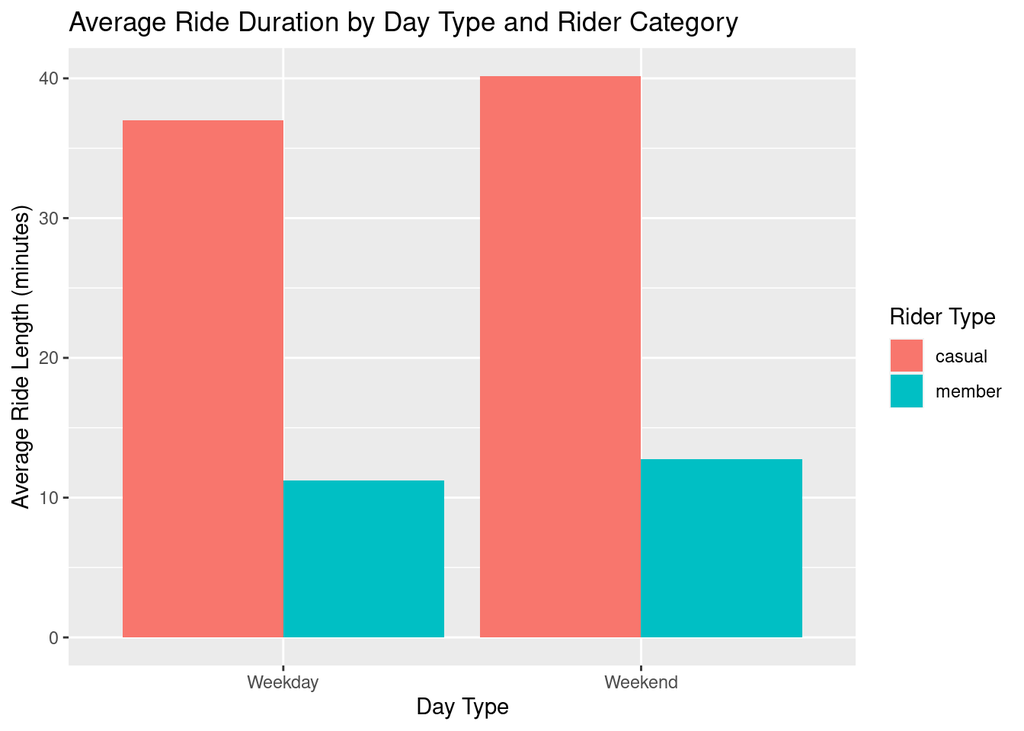

```r
final_summary <- all_trips %>%
  mutate(day_type = if_else(ride_day %in% c("Sat", "Sun"), "Weekend", "Weekday")) %>%
  group_by(member_casual, day_type) %>%
  summarise(rides = n(),
            avg_ride_length = mean(ride_length),
            .groups = "drop")

ggplot(final_summary, aes(x = day_type, y = avg_ride_length, fill = member_casual)) +
  geom_col(position = "dodge") +
  labs(title = "Average Ride Duration by Day Type and Rider Category",
       x = "Day Type",
       y = "Average Ride Length (minutes)",
       fill = "Rider Type")
```

## Ride Volume: Weekend vs Weekday

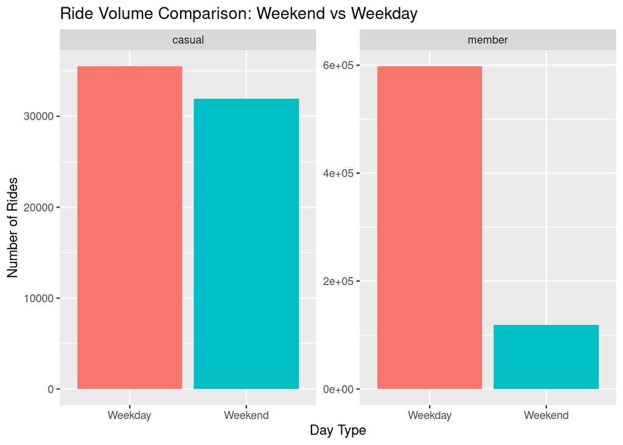

```r
all_trips %>%
  mutate(day_type = if_else(ride_day %in% c("Sat", "Sun"), "Weekend", "Weekday")) %>%
  group_by(member_casual, day_type) %>%
  summarise(rides = n(), .groups = "drop") %>%
  ggplot(aes(x = day_type, y = rides, fill = day_type)) +
  geom_col(show.legend = FALSE) +
  facet_wrap(~ member_casual, scales = "free_y") +
  labs(
    title = "Ride Volume Comparison: Weekend vs Weekday",
    x = "Day Type",
    y = "Number of Rides")
```

## **Business Recommendations**

```
1.  Introduce weekend-focused membership promotions targeted at casual riders.
2.  Offer leisure-oriented membership plans, such as discounted weekend passes.
3.  Use in-app and station-based marketing on weekends when casual ridership peaks.
```